# smoothing

zilani

16 October 2018

```r
# library
library(KernSmooth)
```

**## Data used in here** **(1) “simple data”: created from a the function y = (x^3) * sin((x+3.4)/2)**

**(2) “tough data”: created from two functions and concatenated together.**

**#########################################################################################**

# smoothing

**## Constant-span running mean smoothing** **function y = (x^3) * sin((x+3.4)/2)————————————————————–**

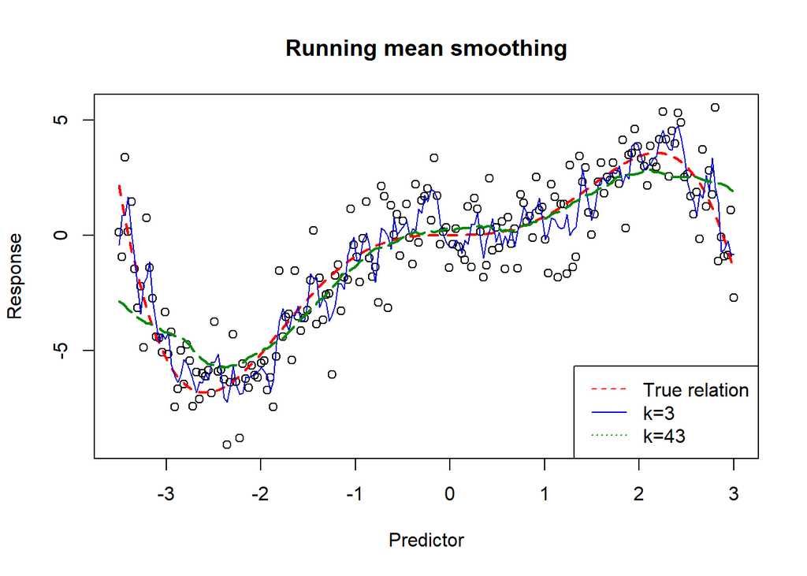

```r
# load data
# set the current directory to be current Rmd file
#path <- dirname(rstudioapi::getActiveDocumentContext()$path)
#setwd(path)

source("functions.R")
easy <- read.table("easysmooth.dat", header=T)
x <- easy$X
y <- easy$Y

# The true relationship
s <- function(x){(x^3) * sin((x+3.4)/2)}

# plot data and create the true relationship line
x.plot <- seq(min(x),max(x),length.out=1000)
y.plot <- s(x.plot)
plot(x, y, xlab="Predictor", ylab="Response", main="Running mean smoothing")
lines(x.plot, y.plot, lty=2, lwd=2, col="red")

s3  <- movingAverage(3,y) # compute moving average with a neighbor of 3
s43 <- movingAverage(43,y) # compute moving average with a neighbor of 43

# plot moving average smoothing
lines(x, s3, col="blue3", lwd=1)
lines(x, s43, lty=5, col="green4", lwd=2)
legend("bottomright",c("True relation","k=3","k=43"),
      lty=c(2,1,3), col=c("red", "blue3", "green4"))
```

**### Determining appropriate span using cross-validated residual sum of squares ———————-**

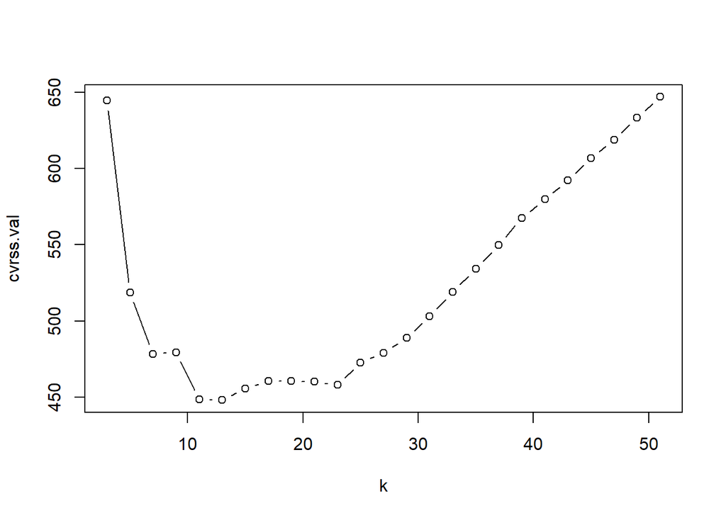

```r
## CVRSS values of k = 3,5,7,...,51
k <- seq(3, 51, by = 2)

## Cross validation
cvrss.val <- rep(0,length(k))
for(i in 1:25){
      cvrss.val[i] <- CVRSS(k[i],y)
}

## plot cross validation results
plot(k,cvrss.val,type="b")
```

```r
## output optimal k value
k[which.min(cvrss.val)]
```

```
## [1] 13
```

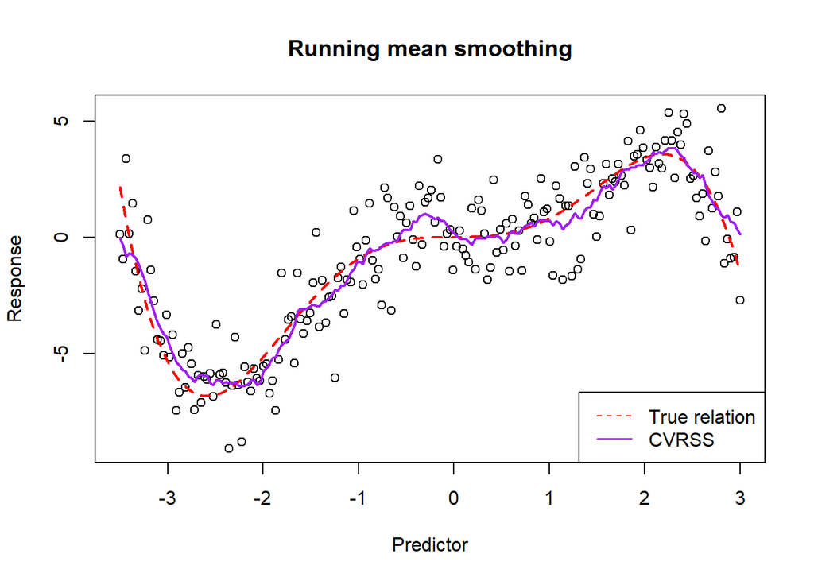

```r
# plot data and create the true relationship line
x.plot <- seq(min(x),max(x),length.out=1000)
y.plot <- s(x.plot)
plot(x, y, xlab="Predictor", ylab="Response", main="Running mean smoothing")
lines(x.plot, y.plot, lty=2, lwd=2, col="red")

# compute moving average with a CVRSS estimated optimal k value
s.hat <- movingAverage(k[which.min(cvrss.val)], y)

# plot moving average smoothing
lines(x, s.hat, col="purple", lwd=2)
legend("bottomright",c("True relation","CVRSS"),
      lty=c(2,1), col=c("red", "purple"))
```

**## Running line smoothing —————————————————————————-**

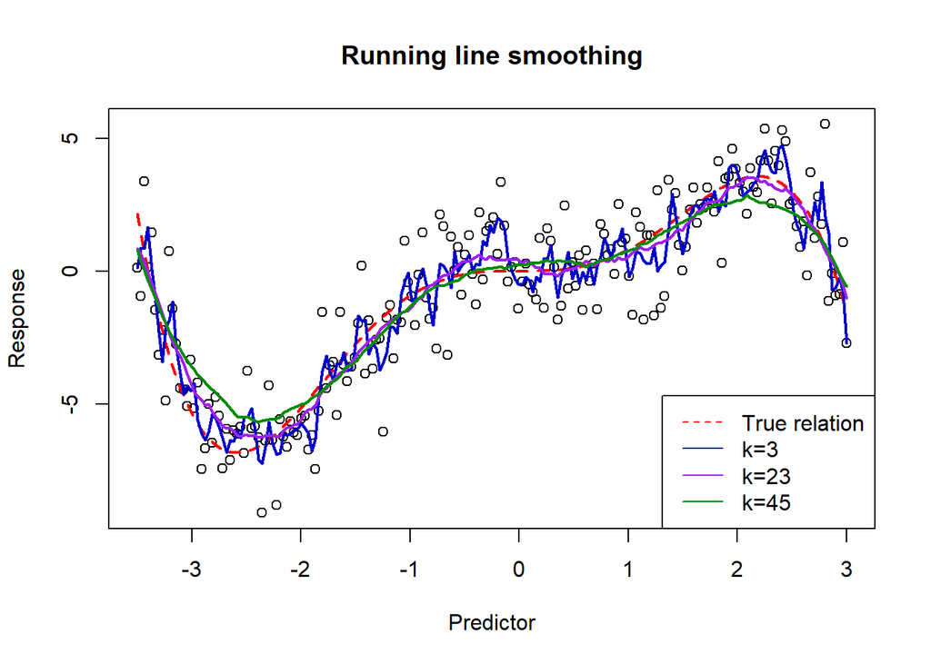

```r
# estimating s using running line smoother with different number of neighbours
s3 <- RLSmoother(3, y, x)
s23 <- RLSmoother(23, y, x)
s45 <- RLSmoother(45, y, x)

# true relationship
s <- function(x){(x^3) * sin((x+3.4)/2)}

# plot range
x.plot <- seq(min(x), max(x), length.out=1000)
y.plot <- s(x.plot)
plot(x, y, xlab="Predictor", ylab="Response", main="Running line smoothing")

lines(x.plot, y.plot, lty=2, lwd=2, col="red")
lines(x, s3, type="l", col="blue3", lwd=2)
lines(x, s23, type="l", col="purple", lwd=2)
lines(x, s45, type="l", col="green4", lwd=2)
legend("bottomright",c("True relation","k=3", "k=23", "k=45"),
      lty=c(2,1,1,1), col=c("red", "blue3", "purple" ,"green4"))
```

**## Kernal smoothing ———————————————————————————-**

```r
# setup the plot of original data and true relationship
x.plot <- seq(min(x), max(x), length.out=1000)
y.plot <- s(x.plot)
plot(x, y, xlab="Predictor", ylab="Response", main="Running line smoothing")
lines(x.plot, y.plot, lty=2, lwd=2, col="red")

# apply kernal smoothing using "KernSmooth" package
library(KernSmooth)
fit <- locpoly(x, y, kernel="normal", bandwidth=0.1)
lines(fit, col="blue3", lwd=2)

fit <- locpoly(x, y, kernel="normal", bandwidth=0.5)
lines(fit, col="green4", lwd=2)

# estimate optimal bandwidth using direct plug-in method in Ruppert, Sheather and Wand (1995).
optimBw <- dpill(x, y)
optimBw
```

```
## [1] 0.1912471
```

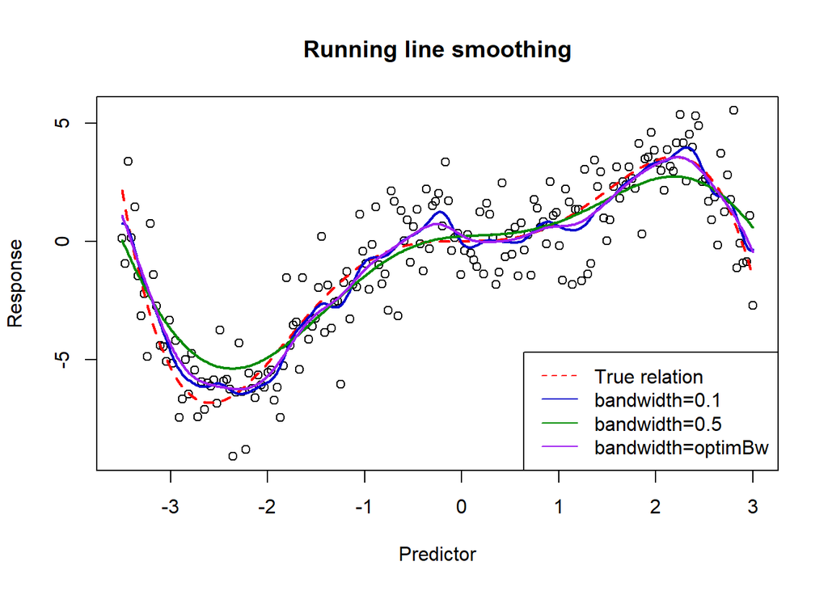

```r
# plot smoothing line with estimated optimal bandwidth
fit <- locpoly(x, y, kernel="normal", bandwidth=optimBw)
lines(fit, col="purple", lwd=2)
legend("bottomright",
  c("True relation", "bandwidth=0.1", "bandwidth=0.5", "bandwidth=optimBw"),
  lty=c(2, 1, 1, 1), col=c("red", "blue3", "green4", "purple"))
```

**## Spline smoothing ———————————————————————————**

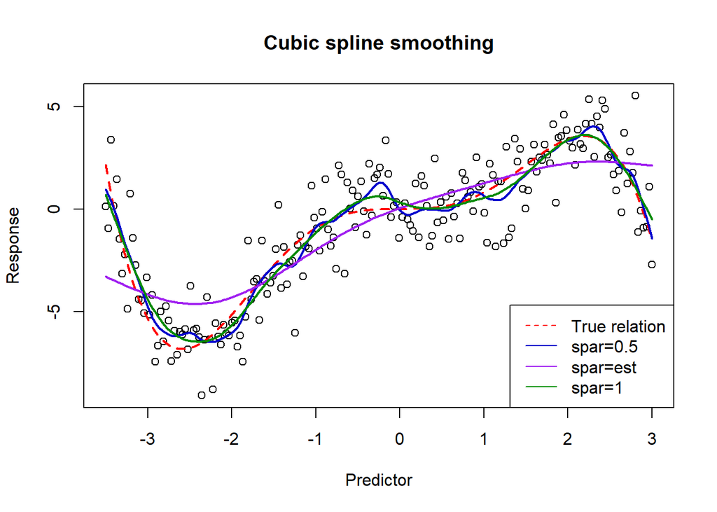

```r
## Use the smooth.spline function in R
cubicSpline1.fit <- smooth.spline(x=x, y=y, cv=FALSE, spar=0.5)
cubicSpline2.fit <- smooth.spline(x=x, y=y, cv=FALSE, spar=1)
cubicSpline3.fit <- smooth.spline(x=x, y=y, cv=TRUE)

## Out put smoothing line
s = function(x){(x^3) * sin((x+3.4)/2)}
x.plot = seq(min(x),max(x),length.out=1000)
y.plot = s(x.plot)
plot(x,y,xlab="Predictor",ylab="Response", main="Cubic spline smoothing")
lines(x.plot, y.plot, lty=2, lwd=2, col="red")
lines(cubicSpline1.fit, col="blue3", lwd=2)
lines(cubicSpline2.fit, col="purple", lwd=2)
lines(cubicSpline3.fit, col="green4", lwd=2)
legend("bottomright",c("True relation","spar=0.5", "spar=est", "spar=1"),
      lty=c(2,1,1,1), col=c("red", "blue3", "purple" ,"green4"))
```

**## Loess smoothing ———————————————————————————-**

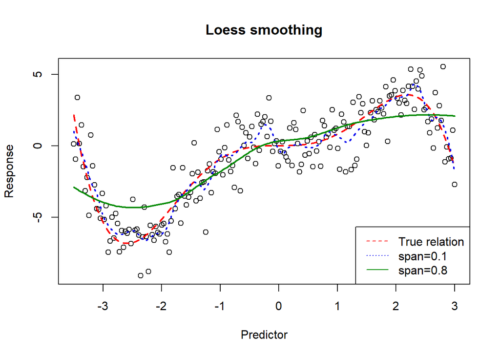

```r
# fitting loess with different spans
lo1.fit <- loess(y~x, span=0.1)
lo2.fit <- loess(y~x, span=0.8)

## Output smoothing results
s = function(x){(x^3) * sin((x+3.4)/2)}
x.plot = seq(min(x),max(x),length.out=1000)
y.plot = s(x.plot)
plot(x, y, xlab="Predictor",ylab="Response", main="Loess smoothing")
lines(x.plot, y.plot, lty=2, col="red", lwd=2)
lines(x, predict(lo1.fit), col="blue2", lwd=2, lty=3)
lines(x, predict(lo2.fit), col="green4", lwd=2)
legend("bottomright",c("True relation","span=0.1", "span=0.8"),
      lty=c(2,3,1), col=c("red", "blue2","green4"))
```

**## Super smoothing ———————————————————————————–**

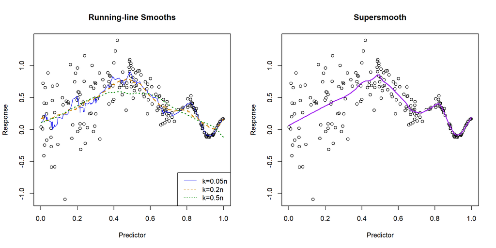

```r
easy <- read.table("toughsmooth.dat", header=T)
x <- easy$X
y <- easy$Y

# create different smoothing parameters for runing line smoothing
n <- length(y)
h <- c(0.05*n, 0.2*n, 0.5*n)

# use R built-in supersmoother
ssmooth.val  = supsmu(x,y)

# apply running line smoothing with different smoothing parameters
rlsmooth.vals = mapply(RLSmoother, h+1, MoreArgs = list(y,x))

## Setup plots
par(mfrow=c(1,2))
plot(x,y,xlab="Predictor",ylab="Response",main="Running-line Smooths")
lines(x,rlsmooth.vals[,1],type="l", col="blue2")
lines(x,rlsmooth.vals[,2],type="l",lty=2, col="orange3", lwd=2)
lines(x,rlsmooth.vals[,3],type="l",lty=3, col="green4", lwd=2)
legend("bottomright",c("k=0.05n","k=0.2n","k=0.5n"), col=c("blue2", "orange3", "green4"), lty=1:3)

plot(x,y,xlab="Predictor",ylab="Response",main="Supersmooth")
lines(ssmooth.val, col="purple", lwd=2)
```

**#######################################################################################################** function(x){(x^3) * cos((x+1.4)/2)}

**### The “datasmooth.txt” contains pairs generated from function(x){(x^3) * cos((x+1.4)/2)} with random noise.**

**### Create a scatter plot of the data and overlay the true relationship line on the plot.**

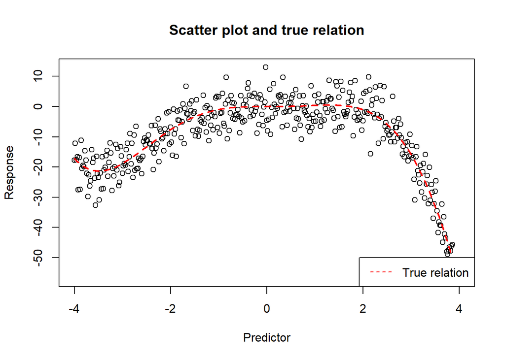

```r
# load data
# set the current directory to be current Rmd file

source("functions.R")
easy <- read.table("datasmooth.txt", header=T)
x <- easy$x
y <- easy$y

# The true relationship
s <- function(x){(x^3) * cos((x+1.4)/2)}

# plot data and create the true relationship line
x.plot <- seq(min(x),max(x),length.out=1000)
y.plot <- s(x.plot)
plot(x, y, xlab="Predictor", ylab="Response", main="Scatter plot and true relation")
lines(x.plot, y.plot, lty=2, lwd=2, col="red")

#s3  <- movingAverage(3,y) # compute moving average with a neighbor of 3
#s43 <- movingAverage(43,y) # compute moving average with a neighbor of 43

# plot moving average smoothing
#lines(x, s3, col="blue3", lwd=1)
#lines(x, s43, lty=5, col="green4", lwd=2)
legend("bottomright",c("True relation"),
      lty=c(2), col=c("red"))
```

**## Determining appropriate span using cross-validated residual sum of squares ————————**

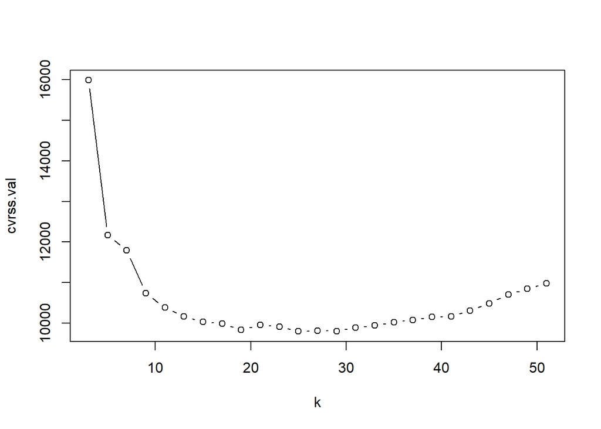

```r
## CVRSS values of k = 3,5,7,...,51
k <- seq(3, 51, by = 2)

## Cross validation
cvrss.val <- rep(0,length(k))
for(i in 1:25){
      cvrss.val[i] <- CVRSS(k[i],y)
}

## plot cross validation results
plot(k,cvrss.val,type="b")
```

```r
## output optimal k value
k[which.min(cvrss.val)]
```

```
## [1] 25
```

**### Try normal kernel smoothing with different bandwidths on “datasmooth.txt”. ——————–**

```r
# setup the plot of original data and true relationship
x.plot <- seq(min(x), max(x), length.out=1000)
y.plot <- s(x.plot)
plot(x, y, xlab="Predictor", ylab="Response", main="Running line smoothing")
lines(x.plot, y.plot, lty=2, lwd=2, col="red")

# apply kernal smoothing using "KernSmooth" package
library(KernSmooth)


# apply kernal smoothing using "KernSmooth" package
library(KernSmooth)
fit <- locpoly(x, y, kernel="normal", bandwidth=0.1)
lines(fit, col="blue3", lwd=2)
fit <- locpoly(x, y, kernel="normal", bandwidth=0.5)
lines(fit, col="green4", lwd=2)

#estimate optimal bandwidth using direct plug-in method in Ruppert, Sheather and Wand (1995).
optimBw <- dpill(x, y)
optimBw
```

```
## [1] 0.2535398
```

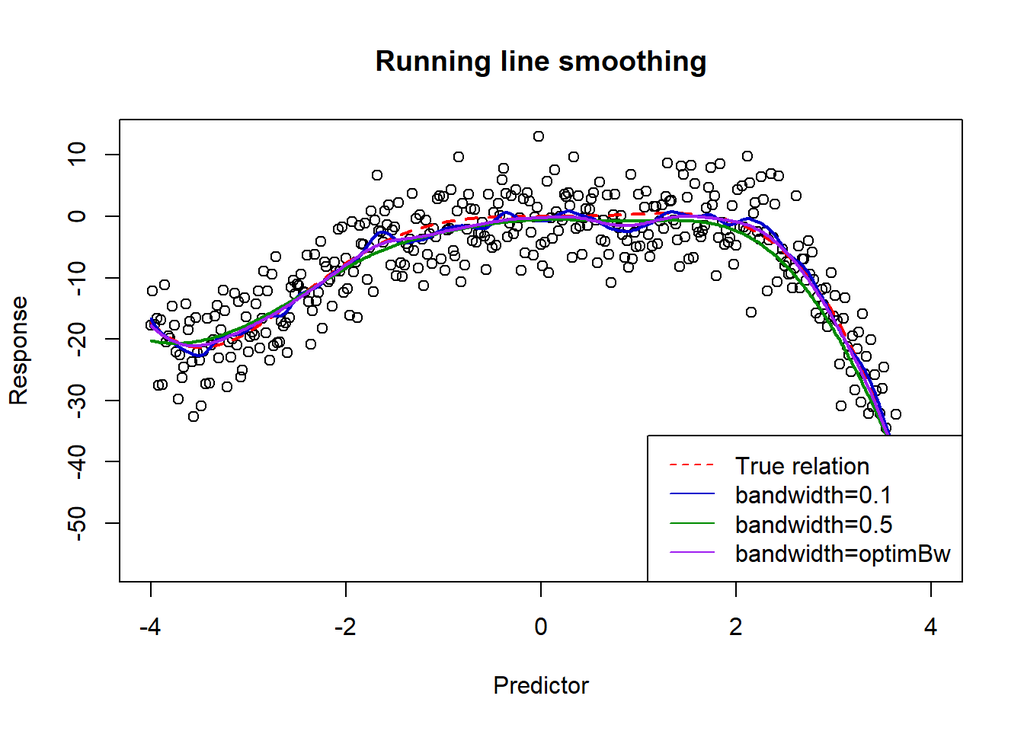

```r
# plot smoothing line with estimated optimal bandwidth
fit <- locpoly(x, y, kernel="normal", bandwidth=optimBw)
lines(fit, col="purple", lwd=2)
legend("bottomright",
  c("True relation", "bandwidth=0.1", "bandwidth=0.5", "bandwidth=optimBw"),
  lty=c(2, 1, 1, 1), col=c("red", "blue3", "green4", "purple"))
```

**### Apply cubic spline with different spars on “datasmooth.txt”. ——————————–**

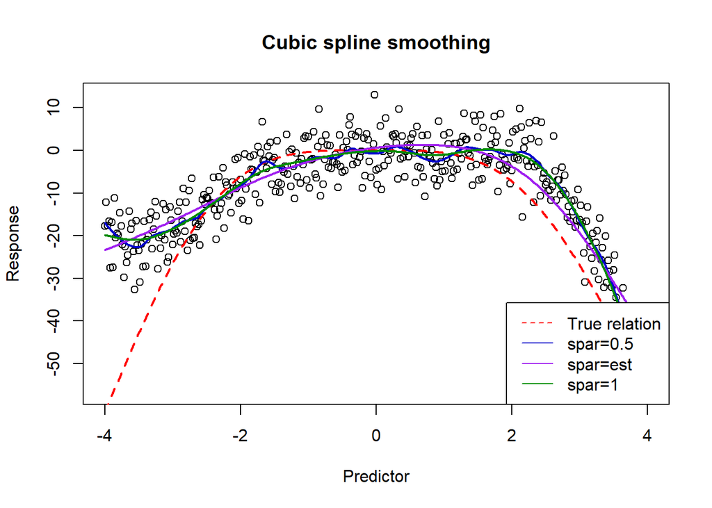

```r
## Spline smoothing

## Use the smooth.spline function in R
cubicSpline1.fit <- smooth.spline(x=x, y=y, cv=FALSE, spar=0.5)
cubicSpline2.fit <- smooth.spline(x=x, y=y, cv=FALSE, spar=1)
cubicSpline3.fit <- smooth.spline(x=x, y=y, cv=TRUE)

## Out put smoothing line
s = function(x){(x^3) * cos((x+3.4)/2)}
x.plot = seq(min(x),max(x),length.out=1000)
y.plot = s(x.plot)
plot(x,y,xlab="Predictor",ylab="Response", main="Cubic spline smoothing")
lines(x.plot, y.plot, lty=2, lwd=2, col="red")
lines(cubicSpline1.fit, col="blue3", lwd=2)
lines(cubicSpline2.fit, col="purple", lwd=2)
lines(cubicSpline3.fit, col="green4", lwd=2)
legend("bottomright",c("True relation","spar=0.5", "spar=est", "spar=1"),
      lty=c(2,1,1,1), col=c("red", "blue3", "purple" ,"green4"))
```

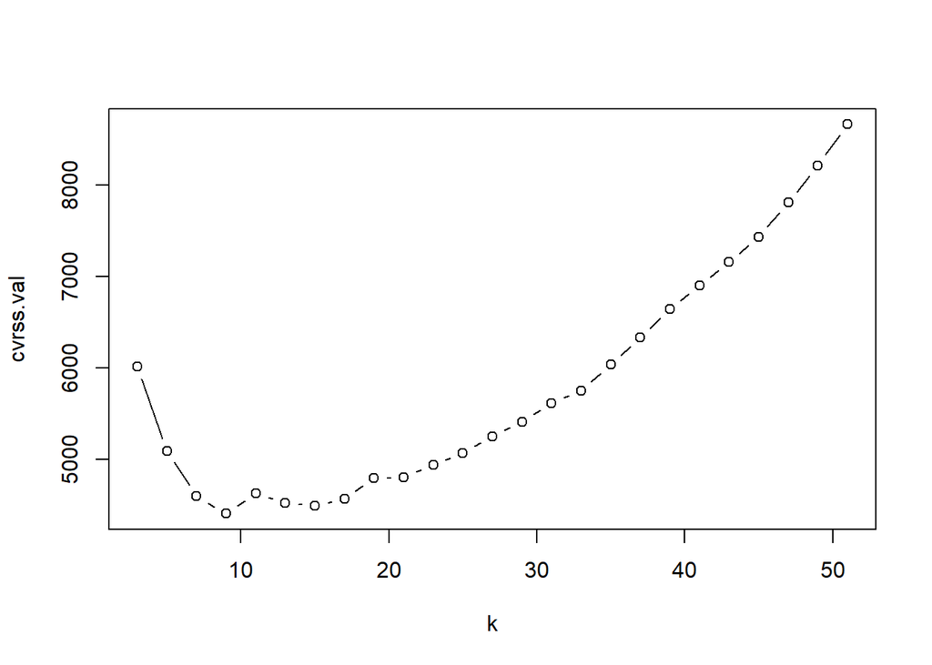

```r
#new data source
easy <- read.table("newdatasmooth.txt", header=T)
x <- easy$x
y <- easy$y

## CVRSS values of k = 3,5,7,...,51
k <- seq(3, 51, by = 2)

## Cross validation
cvrss.val <- rep(0,length(k))
for(i in 1:25){
      cvrss.val[i] <- CVRSS(k[i],y)
}

## plot cross validation results
plot(k,cvrss.val,type="b")
```

```r
## output optimal k value
k[which.min(cvrss.val)]
```

```
## [1] 9
```

```r
# The true relationship
s <- function(x){(x^3) * cos((x+1.4)/2)}

# plot data and create the true relationship line
x.plot <- seq(min(x),max(x),length.out=1000)
y.plot <- s(x.plot)
plot(x, y, xlab="Predictor", ylab="Response", main="Scatter plot and true relation")
lines(x.plot, y.plot, lty=2, lwd=2, col="red")

#s3  <- movingAverage(3,y) # compute moving average with a neighbor of 3
#s43 <- movingAverage(43,y) # compute moving average with a neighbor of 43

# plot moving average smoothing
#lines(x, s3, col="blue3", lwd=1)
#lines(x, s43, lty=5, col="green4", lwd=2)
#legend("bottomright",c("True relation"),
     #lty=c(2), col=c("red"))

# estimate optimal bandwidth using direct plug-in method in Ruppert, Sheather and Wand (1995).
optimBw <- dpill(x, y)
optimBw
```

```
## [1] 0.3034217
```

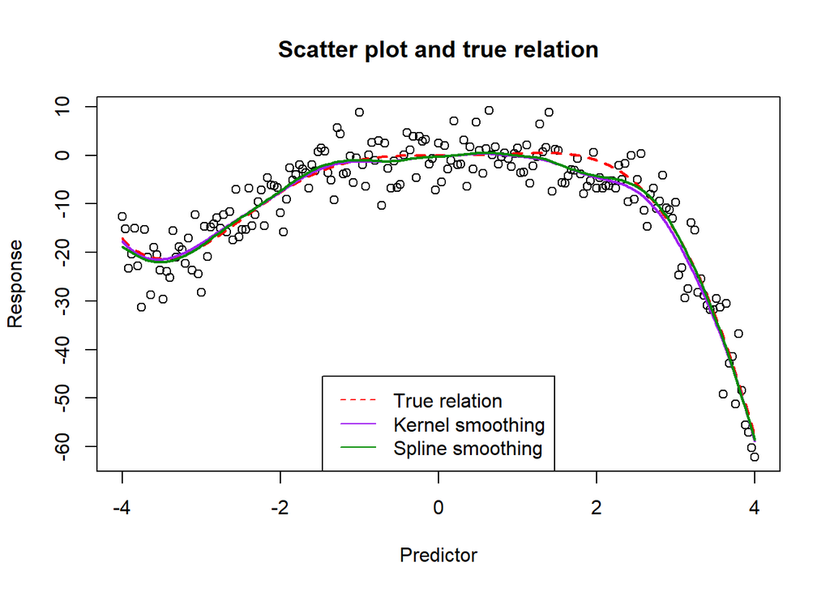

```r
fit <- locpoly(x, y, kernel="normal", bandwidth=optimBw)
lines(fit, col="purple", lwd=2)


cubicSpline.fit <- smooth.spline(x=x, y=y, cv=TRUE)
lines(cubicSpline.fit, col="green4", lwd=2)

legend("bottom",c("True relation","Kernel smoothing","Spline smoothing"),
      lty=c(2,1,1), col=c("red","purple","green4"))
```

**### Normal kernel smoother or cubic spline fits better to “datasmooth.txt”? ———————-**

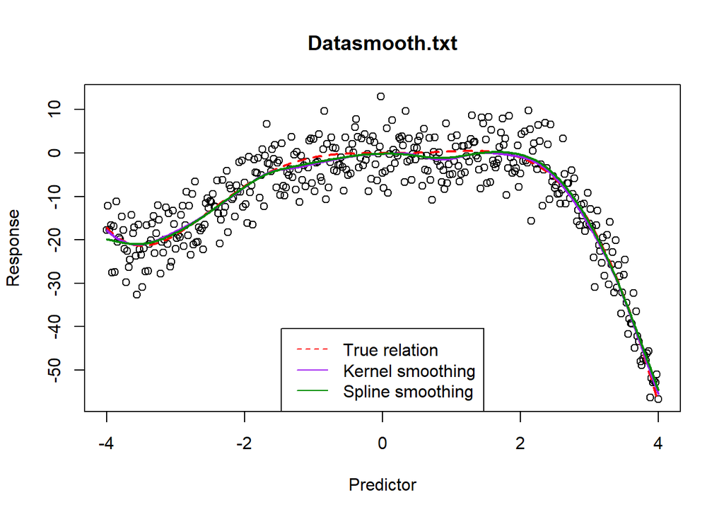

```r
easy <- read.table("datasmooth.txt", header=T)
x <- easy$x
y <- easy$y

# The true relationship
s <- function(x){(x^3) * cos((x+1.4)/2)}

# plot data and create the true relationship line
x.plot <- seq(min(x),max(x),length.out=1000)
y.plot <- s(x.plot)
plot(x, y, xlab="Predictor", ylab="Response", main="Datasmooth.txt")
lines(x.plot, y.plot, lty=2, lwd=2, col="red")


# estimate optimal bandwidth using direct plug-in method in Ruppert, Sheather and Wand (1995).
# MAKE THE KERNAL SMOOTHING WITH PURPLE COLOR
optimBw <- dpill(x, y)
fit <- locpoly(x, y, kernel="normal", bandwidth=optimBw)
lines(fit, col="purple", lwd=2)

# cubic spline smoothing with green line
cubicSpline.fit <- smooth.spline(x=x, y=y, cv=TRUE)
lines(cubicSpline.fit, col="green4", lwd=2)

legend("bottom",c("True relation","Kernel smoothing","Spline smoothing"),
      lty=c(2,1,1), col=c("red","purple","green4"))
```

** BOTH OF THE SMOOTHER FITING ALMOST THE SAME WAY**